# Spotify data analysis

Joy Pham

## Set up

Adding essential libraries in order to do this analysis.

```r
library(readr)
library(DBI)
library(viridis)
library(lubridate)
library(tidyverse)
library(ggplot2)
library(spotifyr)
library(plotly)
library(knitr)
library("gghighlight")
library(jsonlite)
```

As you may notice, there a library called **“spotifyr”**, which was created by GitHub user “charlie86”. This library will allow you to obtain more details using Spotify API. You can find more examples about what you can do with “spotifyr” in this repository: spotifyr

Now, we use functions from our **‘jsonlite’** library to convert our Spotify data file into csv.

```r
## Add 2 JSON files from Spotify data
stream00 <- fromJSON("/Users/joypham/LearningData/LearningR/my_spotify/MyData/StreamingHistory0.json", flatten = TRUE)

stream01 <- fromJSON("/Users/joypham/LearningData/LearningR/my_spotify/MyData/StreamingHistory1.json", flatten = TRUE)
```

Since I have 2 files in my data, I have to merge them into one full file before starting my analysis.

```r
## Merge 2 file into 1 complete file
my_spotify <- rbind(stream00, stream01)
```

Let’s take a glance at our data set.

```r
str(my_spotify)
```

```
'data.frame':   19275 obs. of  4 variables:
 $ endTime   : chr  "2020-08-07 14:18" "2020-09-06 01:47" "2020-09-06 02:06" "2020-09-06 02:07" ...
 $ artistName: chr  "Taylor Swift" "ONE OK ROCK" "ONE OK ROCK" "The Weeknd" ...
 $ trackName : chr  "Everything Has Changed" "We Are" "We Are" "Can't Feel My Face" ...
 $ msPlayed  : int  148331 211323 44078 85440 4392 195924 205133 2169 117165 202586 ...
```

Let’s dig in!

## How many hours per week did you spend on Spotify?

I guess this is one of the first questions popped in your head once you get your Spotify data.

```r
# Adding date and hour
spotify_data <- my_spotify %>%
  as_tibble() %>%
  mutate_at("endTime", ymd_hm) %>%
  mutate(endTime = endTime - hours(6)) %>%
  mutate(date = floor_date(endTime, "day") %>% as_date, seconds = msPlayed / 1000, minutes = seconds / 60)
```

With date, minutes and seconds added, you now can make your first plot to see your activity per week.

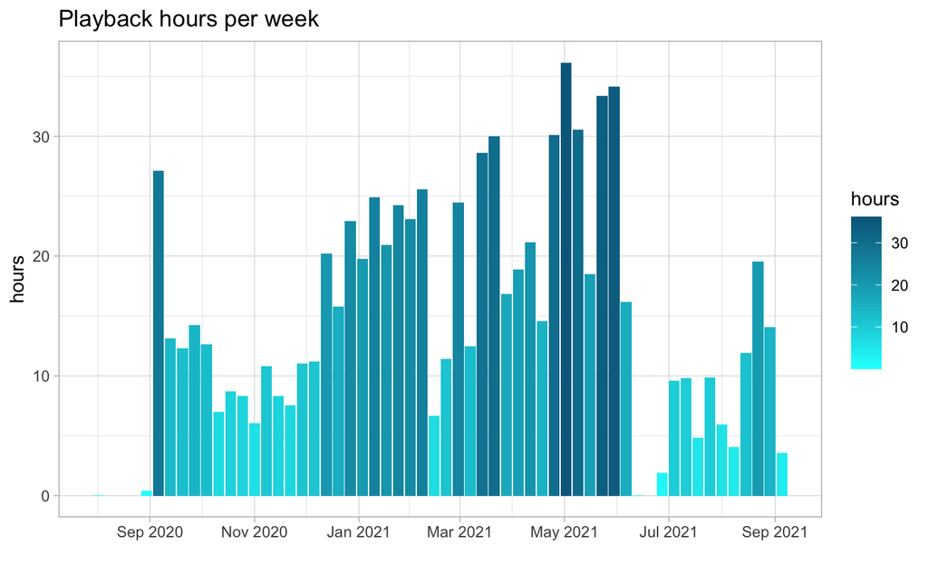

```r
# Playback hours per week
stream_in_hours <- spotify_data %>%
  group_by(date = floor_date(date, "week")) %>%
  summarize(hours = sum(minutes)/60) %>%
  arrange(date) %>%
  ggplot(aes(x = date, y = hours)) +
  geom_col(aes(fill = hours)) +
  scale_x_date(date_labels = "%b %Y", date_breaks= "2 month") +
  scale_fill_gradient(low = "cyan", high = "deepskyblue4") +
  labs(title = "Playback hours per week") +
  xlab("") +
  theme_light()

stream_in_hours
```

```r
NA
```

## Which artist did you spend most time listen to?

You can easily find the answer using the **(“gghighlight”)** library by filtering your data with specific **artistName**.

In my case, I believed I did listen to Taylor Swift and Ed Sheeran a lot.

```r
## Playback per specific artists: Taylor Swift and Ed Sheeran
taylor_ed <- spotify_data %>%
  group_by(artistName, date = floor_date(date, "month")) %>%
  summarize(hours = sum(minutes)/60) %>%
  ggplot(aes(x= date, y= hours, group = artistName, color = artistName)) +
  geom_line() +
  gghighlight(artistName == "Taylor Swift" ||
              artistName == "Ed Sheeran") +
  scale_x_date(date_labels = "%b %Y", date_breaks = "2 month") +
  scale_color_manual(values = c("darkorange2", "maroon")) +
  labs(title = "Playback hours per artist", subtitle = "Taylor Swift vs. Ed Sheeran") +
  xlab("") +
  theme_light()
```

```
label_key: artistName
```

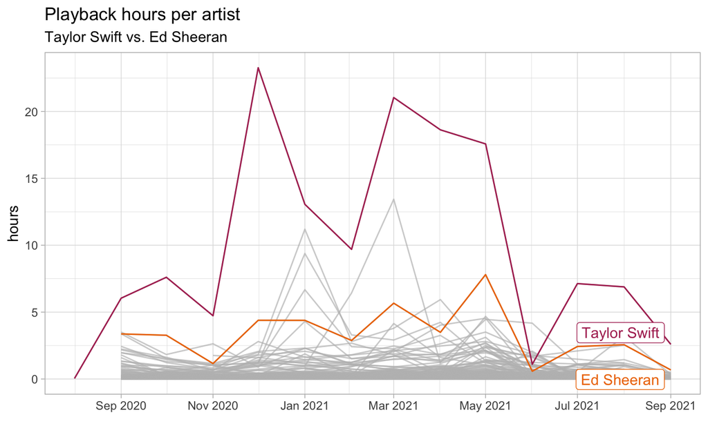

```r
taylor_ed
```

Well, it seems that Taylor did dominate my Spotify. Is it make me a Swiftie?

### JPop

##### Most listened artists

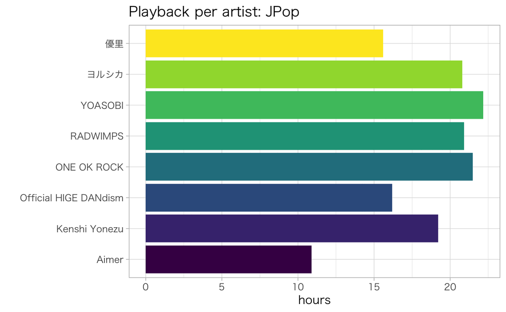

```r
# Playback per specific artists: J-Pop
jpop_artist <- spotify_data %>%
  group_by(artistName, date = floor_date(date, "hour")) %>%
  mutate(artistName = iconv(artistName, to = "UTF-8")) %>%
  filter(artistName == "YOASOBI" ||
         artistName == "Official HIGE DANdism" ||
         artistName == "ヨルシカ" ||
         artistName == "Kenshi Yonezu" ||
         artistName == "優里" ||
         artistName == "ONE OK ROCK" ||
         artistName == "Aimer" ||
         artistName == "RADWIMPS") %>%
  summarize(hours = sum(minutes)/60) %>%
  ggplot(aes(x= artistName, y = hours)) +
  geom_col(aes(fill = artistName))+
  scale_fill_viridis(discrete = TRUE,guide = FALSE, option="D") +
  labs(title = "Playback per artist: JPop") +
  theme_light(base_size=12, base_family="HiraKakuProN-W3") +
  xlab("") +
  coord_flip()
jpop_artist
```

##### Songs per artist

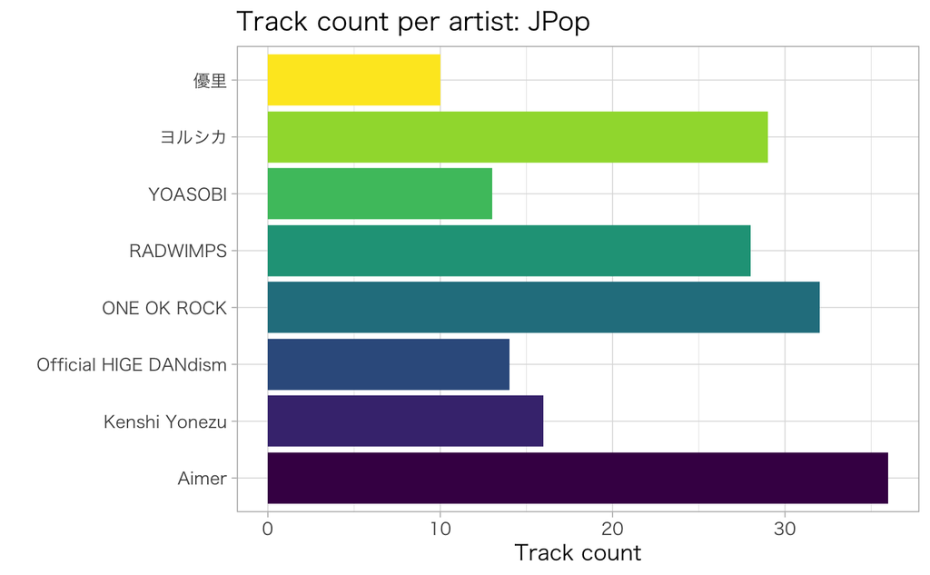

```r
# Track count per artist: JPop
jpop_artist_count <- spotify_data %>%
  group_by(artistName, trackName) %>%
  mutate(artistName = iconv(artistName, to = "UTF-8")) %>%
  filter(artistName == "YOASOBI" ||
         artistName == "Official HIGE DANdism" ||
         artistName == "ヨルシカ" ||
         artistName == "Kenshi Yonezu" ||
         artistName == "優里" ||
         artistName == "ONE OK ROCK" ||
         artistName == "Aimer" ||
         artistName == "RADWIMPS") %>%
  summarize(trackCount = n_distinct(trackName)) %>%
  ggplot(aes(x= artistName, y = trackCount)) +
  geom_col(aes(fill = artistName))+
  scale_fill_viridis(discrete = TRUE,guide = FALSE, option="D") +
  labs(title = "Track count per artist: JPop") +
  theme_light(base_size=12, base_family="HiraKakuProN-W3") +
  xlab("") +
  ylab("Track count") +
  coord_flip()
jpop_artist_count
```

There are a lot of Aimer’s though I mostly skimmed through them. ヨルシカ is another story, I love this band and the deep of their lyrics, specially *suis-san* incredible voice. If you want to bang your head, try ONE OK ROCK.

## Which artist that you listened to most?

Since I’m not sure what a minimum playing hours should be, I will arrange the playing time in descending order and pick top 15 artists. However, you can easily set a minimum threshold by adding a filter.

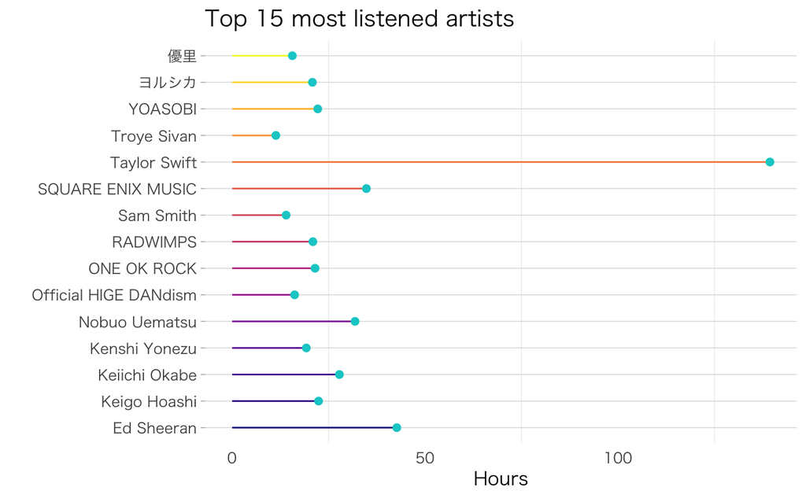

```r
most_listened <- spotify_data %>%
  group_by(artistName) %>%
  mutate(artistName = iconv(artistName, to = "UTF-8")) %>%
  summarize(listenedHours = sum(minutes)/60) %>%
  arrange(desc(listenedHours)) %>%
  slice(1:15) %>%
  ggplot(aes(x = artistName, y = listenedHours,
             color = artistName)) +
  geom_segment(aes(x= artistName, xend= artistName,
                   y= 0, yend = listenedHours)) +
  geom_point(size = 2, color = "cyan3") +
  scale_color_viridis(discrete = TRUE, guide = FALSE, option="C") +
  theme_light(base_size=12, base_family="HiraKakuProN-W3") +
  theme (
    panel.grid.major.x = element_blank(),
    panel.border = element_blank(),
    axis.ticks.x = element_blank(),
  ) +
  labs(title = "Top 15 most listened artists") +
  xlab("") +
  ylab("Hours") +
  coord_flip()

most_listened
```

```r
NA
```

Oh, it’s Taylor, again! She definitely rule my Spotify! I just realize that I listened to a lot of game soundtracks. Most of them are from Final Fantasy franchises and NieR series, both are belongs to Square Enix.

## And, who have the most songs?

Actually, I can guess the result already. But, let’s check!

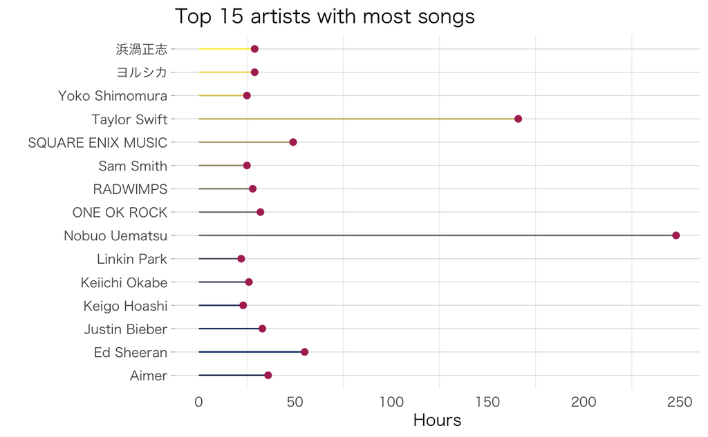

```r
most_songs <- spotify_data %>%
  group_by(artistName) %>%
  mutate(artistName, iconv(artistName, to = "UTF-8")) %>%
  summarize(total_songs = n_distinct(trackName)) %>%
  arrange(desc(total_songs)) %>%
  slice(1:15) %>%
  ggplot(aes(x= artistName, y= total_songs, color= artistName)) +
  geom_segment(aes(x= artistName, xend= artistName, y= 0, yend= total_songs)) +
  geom_point(size= 2, color= "maroon") +
  scale_color_viridis(discrete = TRUE, guide = FALSE, option="E") +
  theme_light(base_size=12, base_family="HiraKakuProN-W3") +
  theme (
    panel.grid.major.x = element_blank(),
    panel.border = element_blank(),
    axis.ticks.x = element_blank(),
  ) +
  labs(title = "Top 15 artists with most songs") +
  xlab("") +
  ylab("Hours") +
  coord_flip()

most_songs
```

Finally, there’s a battle that Taylor would lose. Roughly 250 songs from Nobuo Uematsu! Yup, that’s Final Fantasy franchises.

## You can also check if times spent on an artist has any relationship with the number of song from him/ her.

As you may know, to check whether 2 variables are related to each other, we would use scatterplot.

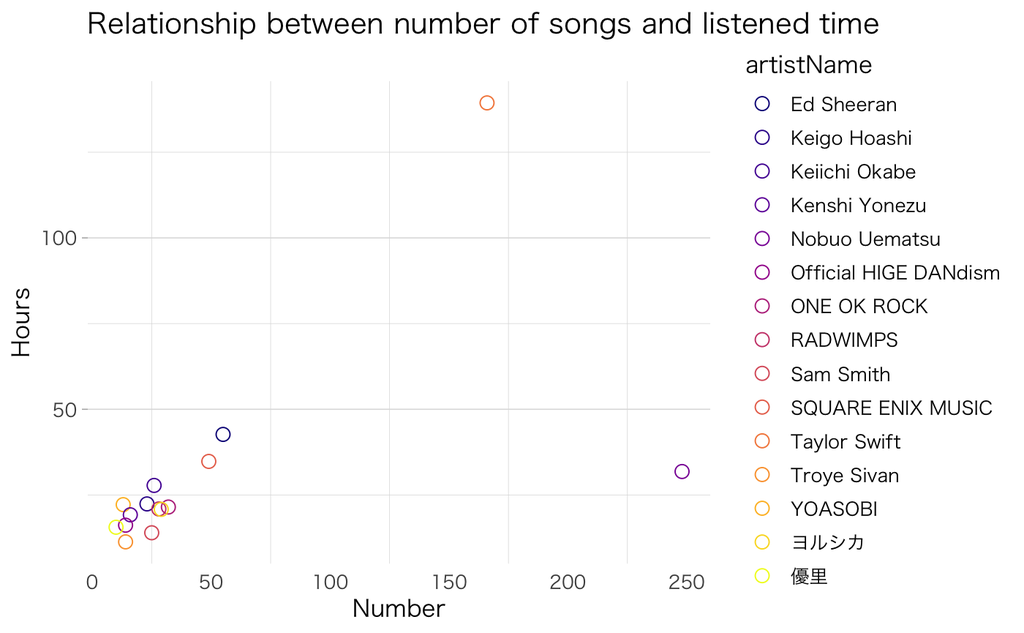

```r
# Listened time vs. number of songs
listenedTimes_songs <- spotify_data %>%
  group_by(artistName) %>%
  mutate(artistName = iconv(artistName, to = "UTF-8")) %>%
  summarize(listenedHours = sum(minutes)/60, total_songs= n_distinct(trackName)) %>%
  arrange(desc(listenedHours, total_songs)) %>%
  slice(1:15) %>%
  ggplot(aes(x = total_songs, y = listenedHours,color = artistName)) +
  geom_point(size = 3, shape = 21 ) +
  scale_color_viridis(discrete = TRUE, option="C") +
  theme_light(base_size=12, base_family="HiraKakuProN-W3") +
  theme (
    panel.grid.major.x = element_blank(),
    panel.border = element_blank(),
    axis.ticks.x = element_blank(),
  ) +
  labs(title = "Relationship between number of songs and listened time
       ") +
  xlab("Number") +
  ylab("Hours")

listenedTimes_songs
```

So, it seems that the number of songs has nothing to do with the time listened of an artist. Still, it’s quite funny to see Taylor’s lonely ring on the top of the graph.

## Most listened songs

I guess apart from artists, you would wonder which songs you got hooked the most. Let’s check our top 15 most listened songs.

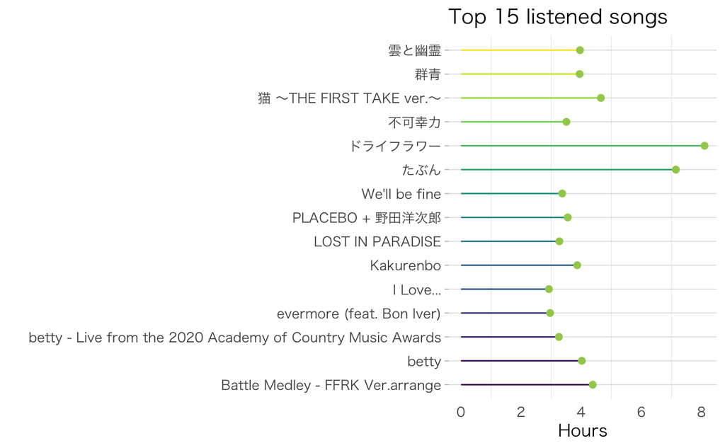

```r
# Top 15 most listened songs
top_songs <- spotify_data %>%
  group_by(trackName) %>%
  summarize(hours= sum(minutes)/60) %>%
  arrange(desc(hours)) %>%
  slice(1:15) %>%
  ggplot(aes(x= trackName, y= hours, color= trackName)) +
  geom_segment(aes(x= trackName, xend= trackName, y= 0, yend= hours)) +
  geom_point(size= 2, color= "darkolivegreen3") +
  scale_color_viridis(discrete = TRUE, guide = FALSE, option="D") +
  theme_light(base_size=12, base_family="HiraKakuProN-W3") +
  theme (
    panel.grid.major.x = element_blank(),
    panel.border = element_blank(),
    axis.ticks.x = element_blank(),
  ) +
  labs(title = "Top 15 listened songs") +
  xlab("") +
  ylab("Hours") +
  coord_flip()

top_songs
```

Though Taylor is my most listened artist, 11/15 of my most listened songs were Japanese, with ドライフラワー(Dried Flower) by 優里(Yuuri) and たぶん(Probably) by YOASOBI outweighted other songs.

## During the day, which hours you spent on Spotify most?

We’ll make a plot with total hours to have an overall look which part of the day you got hook in Spotify.

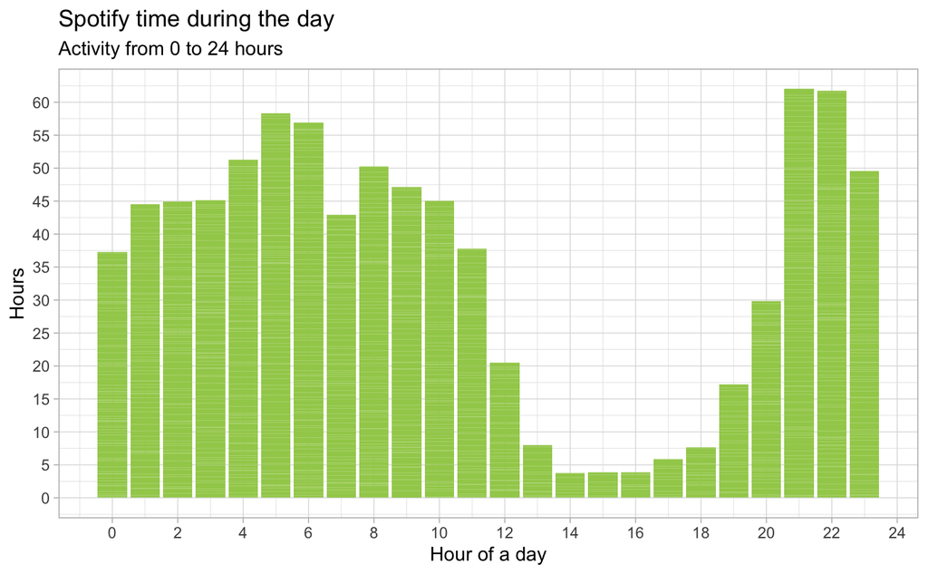

```r
# Playback hour
dayHour <- spotify_data %>%
  group_by(date, hour = hour(endTime), weekday = wday(date, label = TRUE)) %>%
  summarize(hoursListened = sum(minutes)/60)
dayHour %>%
  ggplot(aes(x= hour, y= hoursListened, group= date)) +
  geom_col(fill = "darkolivegreen3") +
  scale_fill_brewer(palette = 3) +
  scale_x_continuous(breaks = seq(0, 24, 2)) +
  scale_y_continuous(breaks = seq(0, 60, 5)) +
  labs(title = "Spotify time during the day", subtitle = "Activity from 0 to 24 hours") +
  xlab("Hour of a day") +
  ylab("Hours") +
  theme_light()
```

```r
NA
NA
```

Oops, what a surprise! I never think I spent most of my time on Spotify during sleeping hours. It might be when I had to worked on night shifts but still, this is quite shock to see. In brief, it’s obvious that I used Spotify all day.

## During the week, what day you listened to Spotify most

You already have a plot of your listening hours during the day, but how about during the week? You spend most of yout Spotify time on weekdays or weekends? Let’s try it with a heatmap.

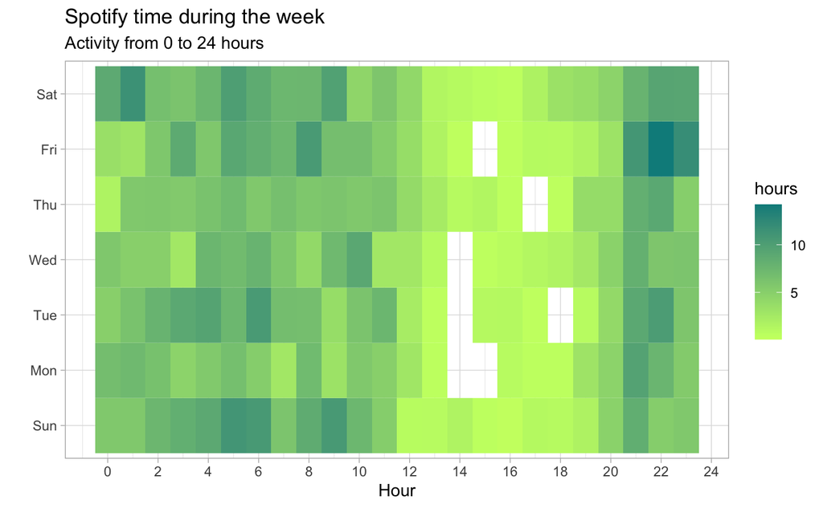

```r
# Playback activity during the week
dayHour %>%
  group_by(weekday, hour) %>%
  summarize(hours = sum(hoursListened)) %>%
  ggplot(aes(x= hour, y= weekday, fill= hours)) +
  geom_tile() +
  scale_x_continuous(breaks= seq(0, 24, 2)) +
  scale_fill_gradient(low= "darkolivegreen1", high= "cyan4") +
  labs(title= "Spotify time during the week", subtitle= "Activity from 0 to 24 hours",
       x= "Hour", y= "") +
  theme_light()
```

```r
NA
```

As I almost used Spotify non-stop, my time on the app during the week also reflect the same story though I’m sure it’s not healthy at all.

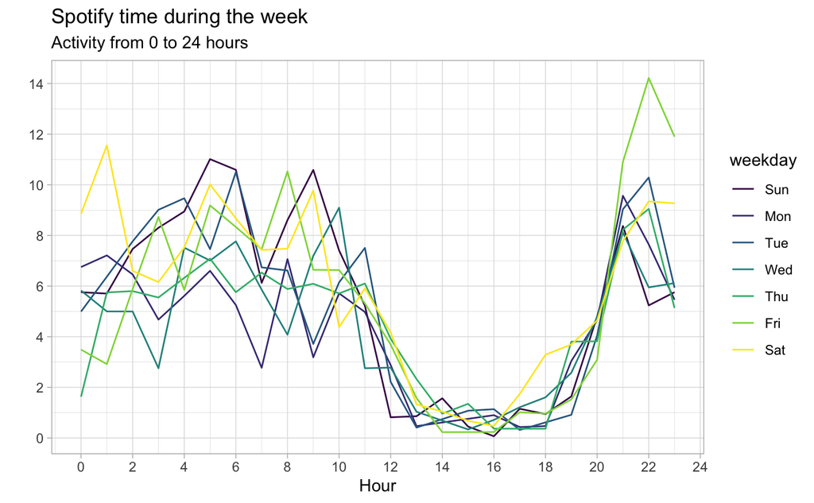

```r
weekHour <- dayHour %>%
  group_by(weekday, hour) %>%
  summarize(hours = sum(hoursListened)) %>%
  ggplot(aes(x= hour, y= hours, color= weekday)) +
  geom_line() +
  scale_color_viridis(discrete= TRUE, option= "D") +
  scale_x_continuous(breaks= seq(0, 24, 2)) +
  scale_y_continuous(breaks= seq(0, 15, 2)) +
  scale_fill_gradient(low= "darkolivegreen1", high= "cyan4") +
  labs(title= "Spotify time during the week", subtitle= "Activity from 0 to 24 hours",
       x= "Hour", y= "") +
  theme_light()
weekHour
```

Using a line plot, it can be seen that I spent a bit more time with Spotify on Friday around 22 o’clock than other days. And, it looks like in my unhealthy listening pattern, Monday is my least favorite day.